# HW 10

Yifan Wu

May 1, 2018

## 9.7.3

### (a).

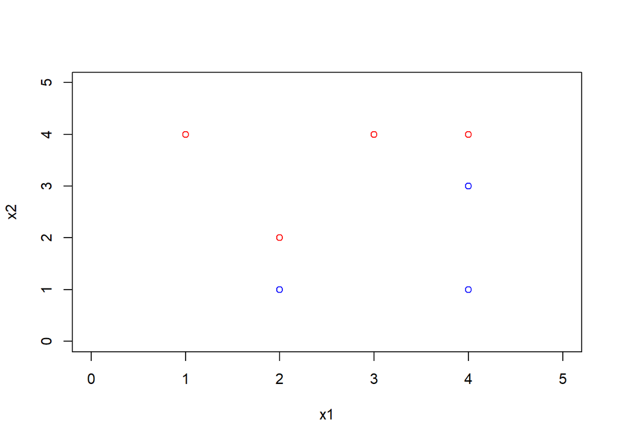

```r
rm(list = setdiff(ls(), lsf.str()))

x1 = c(3, 2, 4, 1, 2, 4, 4)
x2 = c(4, 2, 4, 4, 1, 3, 1)
colors = c("red", "red", "red", "red", "blue", "blue", "blue")
plot(x1, x2, col = colors, xlim = c(0, 5), ylim = c(0, 5))
```

### (b).

The optimal hyperplane should be between the line $(2,1)$ $(4,3)$ lies on, and the line $(2,2)$,$(4,4)$ lies on. That is the line parallel to those two lines with equal distance to those two lines.

The equation for the optimal hyperplane is: $y = x - \frac{1}{2}$.

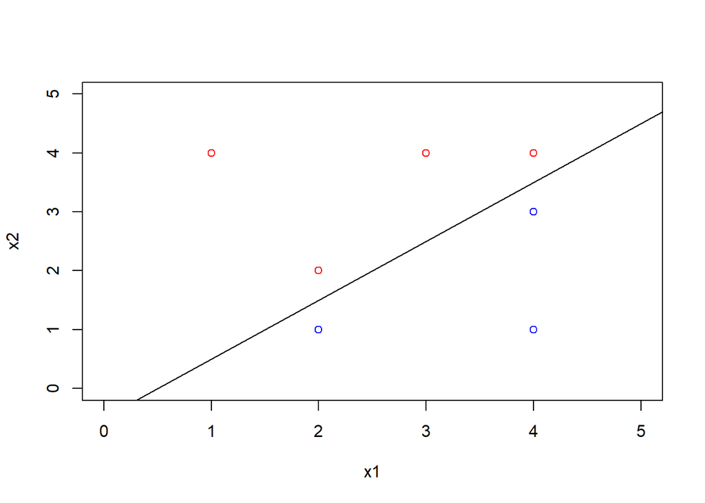

```r
plot(x1, x2, col = colors, xlim = c(0, 5), ylim = c(0, 5))
abline(-0.5, 1)
```

### (d).

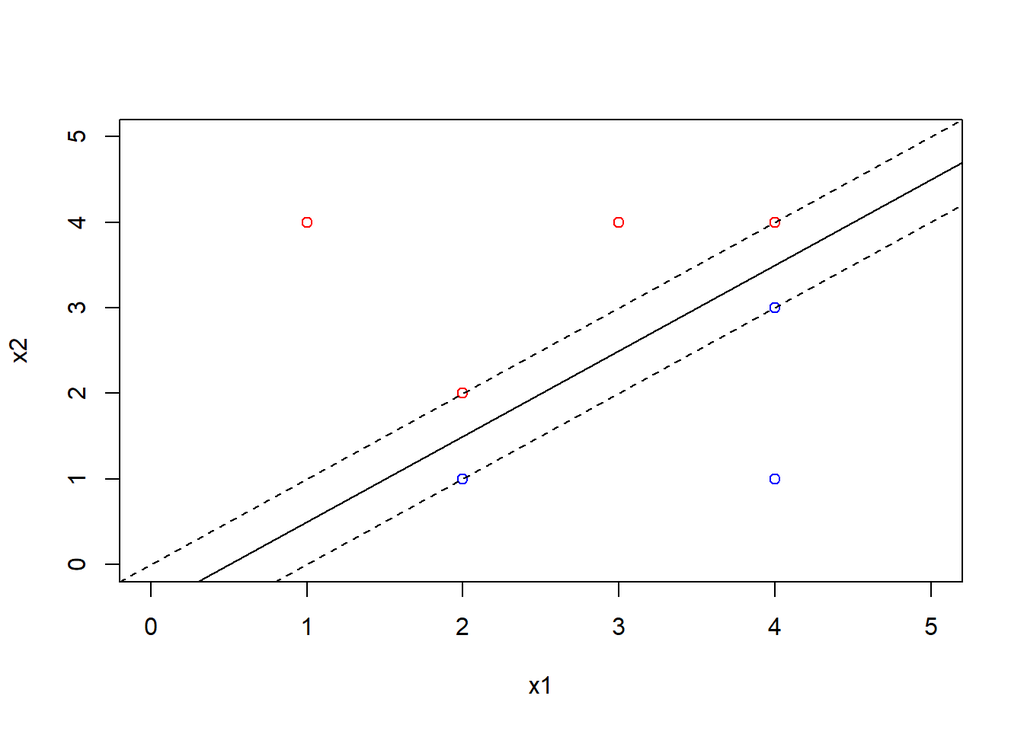

```r
plot(x1, x2, col = colors, xlim = c(0, 5), ylim = c(0, 5))
abline(-0.5, 1)
abline(-1, 1, lty = 2)
abline(0, 1, lty = 2)
```

### (e).

The support vectors are: $(2,1)$, $(4,3)$, $(2,2)$,$(4,4)$.

### (f).

The seventh point is not a support vector.

### (g).

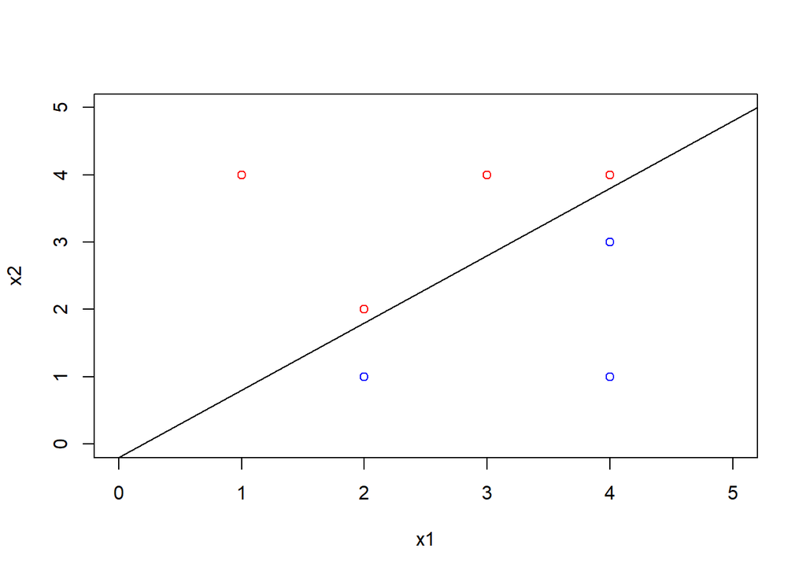

```r
plot(x1, x2, col = colors, xlim = c(0, 5), ylim = c(0, 5))
abline(-0.2, 1)
```

### (h).

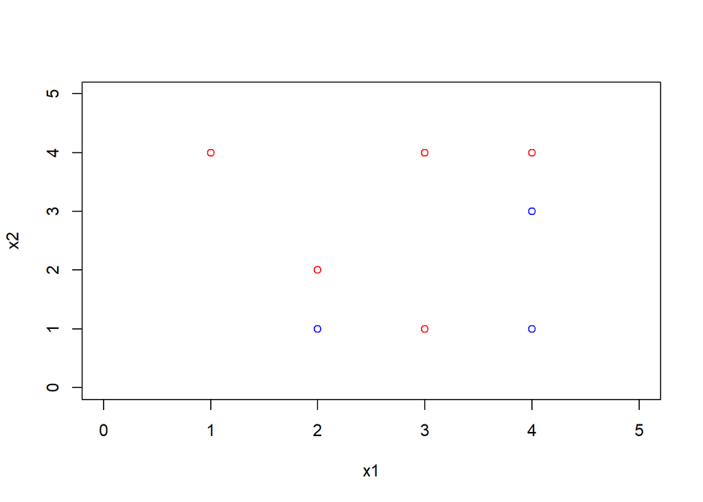

```r
plot(x1, x2, col = colors, xlim = c(0, 5), ylim = c(0, 5))
points(c(3), c(1), col = c("red"))
```

## 9.7 #4

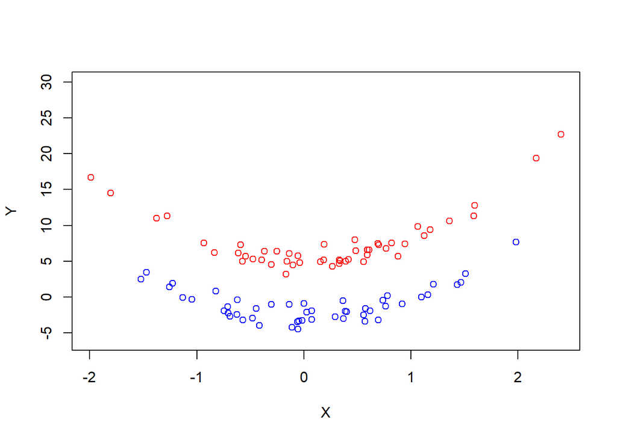

```r
library(e1071)
set.seed(1)
x <- rnorm(100)
y <- 3 * x^2 + 1 + rnorm(100)
class <- sample(100, 50)
y[class] <- y[class] + 4
y[-class] <- y[-class] - 4
plot(x[class], y[class], col = "red", xlab = "X", ylab = "Y", ylim = c(-6, 30))
points(x[-class], y[-class], col = "blue")
```

```r
z <- rep(-1, 100)
z[class] <- 1
data <- data.frame(x = x, y = y, z = as.factor(z))
train <- sample(100, 50)
data.train <- data[train, ]
data.test <- data[-train, ]
```

For Support Vector Classifier:

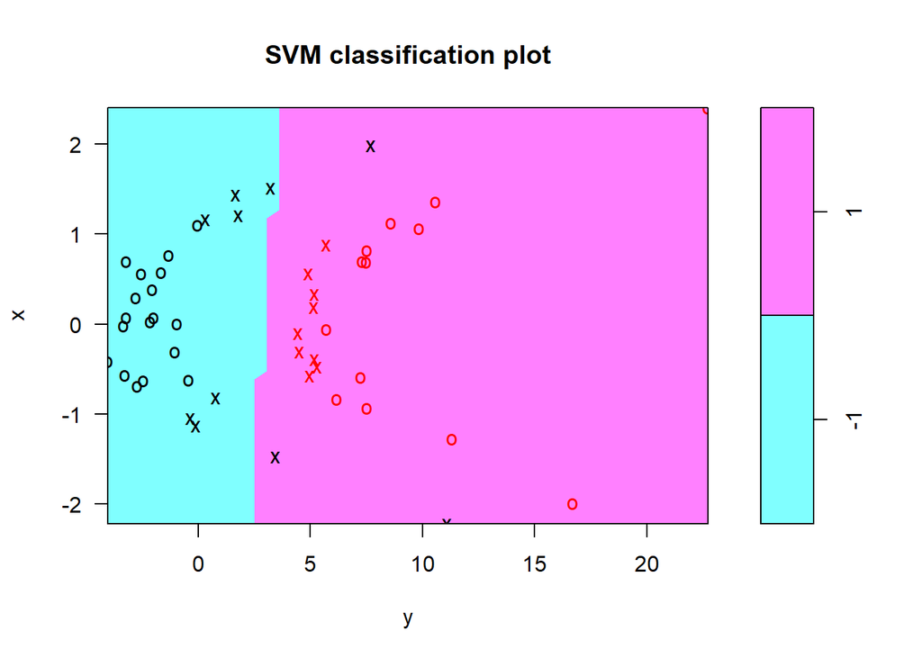

```r
svm.linear <- svm(z ~ ., data = data.train, kernel = "linear", cost = 1)
plot(svm.linear, data.train)
```

```r
table.linear.train = table(predict = predict(svm.linear, data.train), truth = data.train$z)
table.linear.train
```

```
##        truth
## predict -1  1
##      -1 24  0
##      1   4 22
```

```r
(table.linear.train[2] + table.linear.train[3])/sum(table.linear.train)
```

```
## [1] 0.08
```

```r
table.linear.test = table(predict = predict(svm.linear, data.test), truth = data.test$z)
table.linear.test
```

```
##        truth
## predict -1  1
##      -1 21  0
##      1   1 28
```

```r
(table.linear.test[2] + table.linear.test[3])/sum(table.linear.test)
```

```
## [1] 0.02
```

Next, we fit a support vector machine with a polynomial kernel.

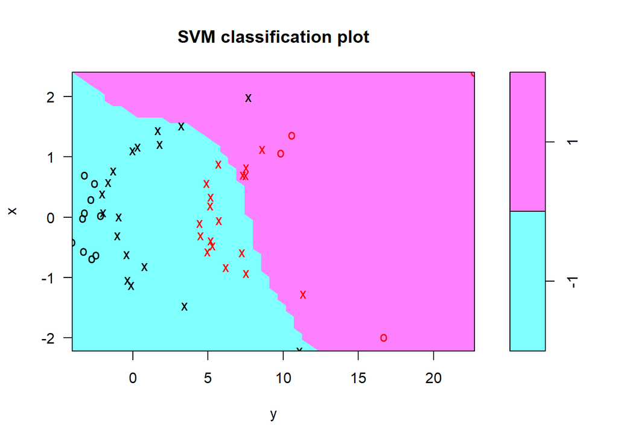

```r
svm.poly <- svm(z ~ ., data = data.train, kernel = "polynomial", cost = 1)
plot(svm.poly, data.train)
```

```r
table.poly.train = table(predict = predict(svm.poly, data.train), truth = data.train$z)
table.poly.train
```

```
##        truth
## predict -1  1
##      -1 27 13
##      1   1  9
```

```r
(table.poly.train[2] + table.poly.train[3])/sum(table.poly.train)
```

```
## [1] 0.28
```

```r
table.poly.test = table(predict = predict(svm.poly, data.test), truth = data.test$z)
table.poly.test
```

```
##        truth
## predict -1  1
##      -1 22 18
##      1   0 10
```

```r
(table.poly.test[2] + table.poly.test[3])/sum(table.poly.test)
```

```
## [1] 0.36
```

Next we use radial kernel:

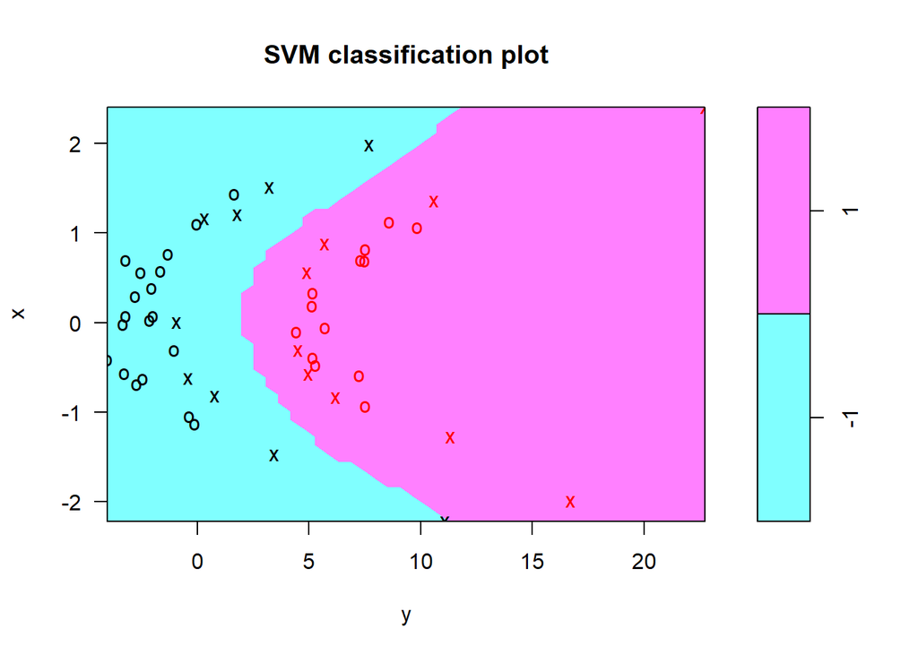

```r
svm.radial <- svm(z ~ ., data = data.train, kernel = "radial", cost = 1)
plot(svm.radial, data.train)
```

```r
table.radial.train = table(predict = predict(svm.radial, data.train), truth = data.train$z)
table.radial.train
```

```
##        truth
## predict -1  1
##      -1 27  0
##      1   1 22
```

```r
(table.radial.train[2] + table.radial.train[3])/sum(table.radial.train)
```

```
## [1] 0.02
```

```r
table.radial.test = table(predict = predict(svm.radial, data.test), truth = data.test$z)
table.radial.test
```

```
##        truth
## predict -1  1
##      -1 22  0
##      1   0 28
```

```r
(table.radial.test[2] + table.radial.test[3])/sum(table.radial.test)
```

```
## [1] 0
```

In the case of Linear SV clasisfier, the training and test error: 0.08 and 0.02. In the case of polynomial kernal SVM, the training and test error: 0.28 and 0.36. In the case of radial kernal SVM, the training and test error: 0.02 and 0.

From the above result we can see that radial kernal SVM outperforms Linear SV Classifier.

## 10.7 #2a-d

### (a).

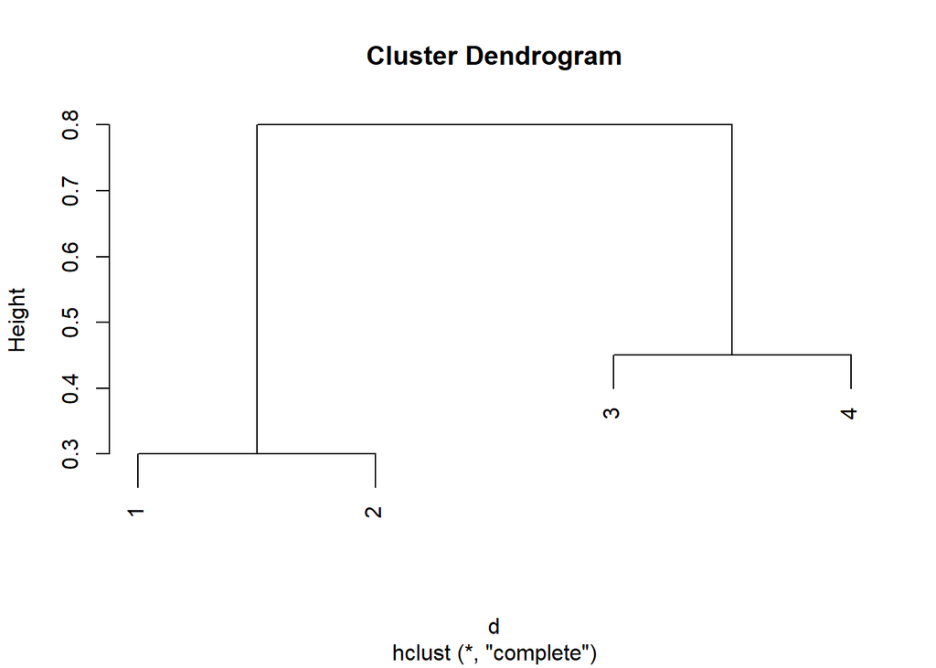

```r
d = as.dist(matrix(c(0, 0.3, 0.4, 0.7,
                     0.3, 0, 0.5, 0.8,
                     0.4, 0.5, 0.0, 0.45,
                     0.7, 0.8, 0.45, 0.0), nrow = 4))
plot(hclust(d, method = "complete"))
```

### (b).

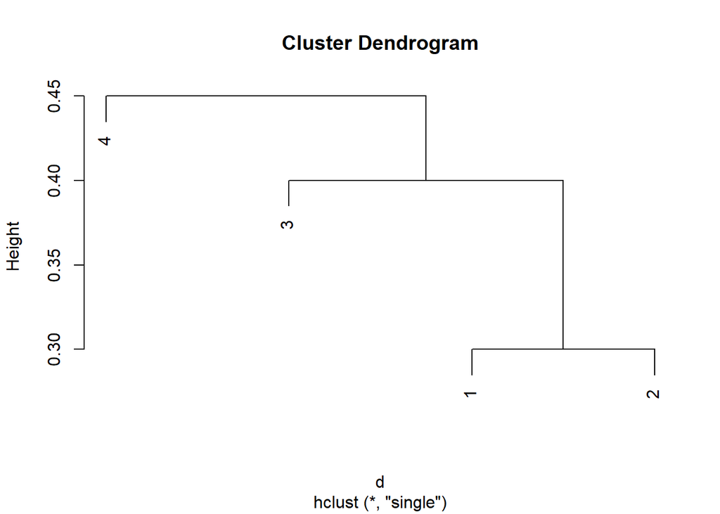

```r
plot(hclust(d, method = "single"))
```

### (c).

In this case, we have clusters (1,2) and (3,4).

### (d).

In this case, we have clusters ((1,2),3) and (4).

## 10.7 #11

### (a).

```r
genes <- read.csv(url("http://www-bcf.usc.edu/~gareth/ISL/Ch10Ex11.csv"), header = FALSE)
```

### (b).

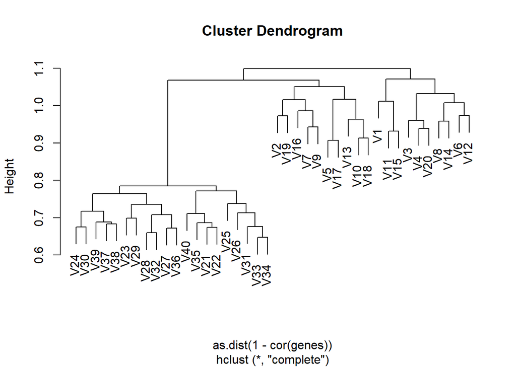

```r
hc.complete <- hclust(as.dist(1 - cor(genes)), method = "complete")
plot(hc.complete)
```

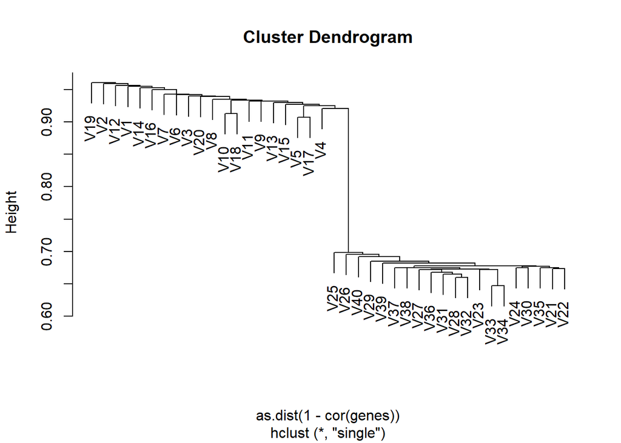

```r
hc.single <- hclust(as.dist(1 - cor(genes)), method = "single")
plot(hc.single)
```

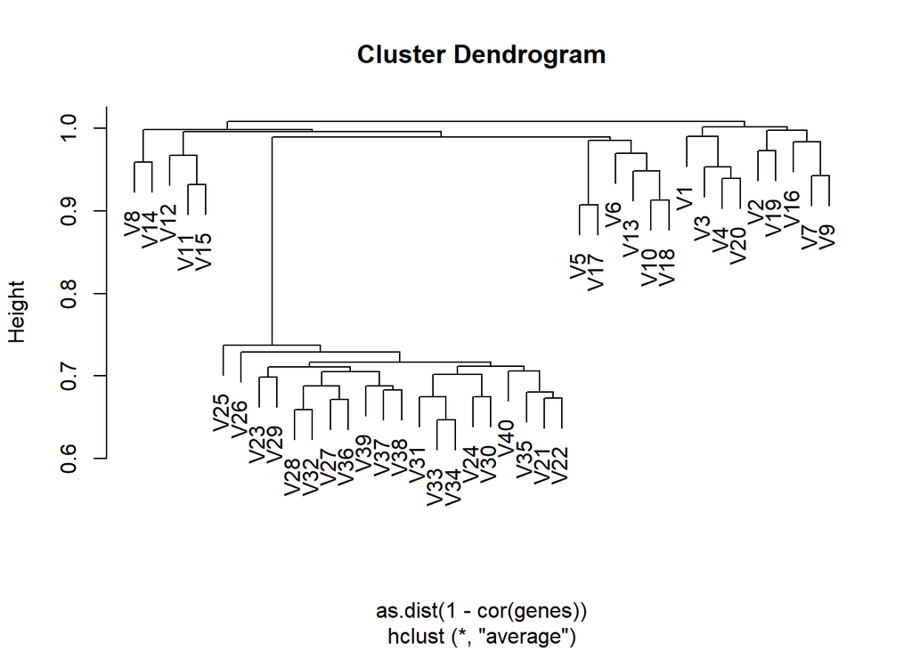

```r
hc.average <- hclust(as.dist(1 - cor(genes)), method = "average")
plot(hc.average)
```

From the clustering result above we can see that we get two cluste from complete and single linkage, and three clusters from average linkage.

### (c).

If we want to know the genes that differs the most,

```r
pr.out <- prcomp(t(genes),scale =TRUE)#PCA on the transpose of data matrix while normalize the data. We want to examine the variance of genes, so we have to transpose the dataset.

dim(pr.out$rotation)#The dimension of rotation matrix, which is the loading of each principle components on each observation of data.
```

```
## [1] 1000   40
```

```r
head(pr.out$rotation)
```

```
##               PC1         PC2          PC3          PC4          PC5
## [1,] -0.005248643  0.02924652 -0.003735358 -0.016526153  0.006318053
## [2,] -0.002162728  0.04373711 -0.071475379  0.036521467 -0.010739305
## [3,]  0.014444163  0.01361593 -0.011068681 -0.075011306  0.002396073
## [4,]  0.014868417 -0.01975169 -0.038690207  0.018872555 -0.007595757
## [5,]  0.010600362 -0.02949636  0.016983813  0.005730388 -0.019518632
## [6,]  0.030133863  0.03181327  0.016420667  0.016799619  0.037829117
##               PC6         PC7           PC8          PC9         PC10
## [1,] -0.049838208 -0.01283006  0.0215726238  0.007640568 -0.042478511
## [2,]  0.044918065  0.02817240 -0.0372224597 -0.030437604  0.077891794
## [3,] -0.073571187 -0.03590103  0.0385994243  0.013067476  0.004386205
## [4,] -0.006314036  0.04078925  0.0032669777  0.013650293 -0.003238640
## [5,]  0.025142879  0.03502170  0.0357811899  0.036519007 -0.078427052
## [6,]  0.076979558  0.01745551  0.0002496599 -0.037883486  0.001399260
##             PC11         PC12         PC13          PC14         PC15
```

[output cut: 41 more lines]

```r
total.load <- apply(pr.out$rotation, 1, sum) #Sum over all columns for all 1000 genes
index <- order(abs(total.load), decreasing = TRUE)#Ordering to find the largest absolute total loading
index[1:10]
```

```
##  [1] 889 676 755 960 907  19 475 673 374 174
```

The 10 most variable genes are shown above.